# Módulo: Regresión y Correlación

## T11a: Regresión lineal simple y múltiple

# Objetivos de la clase

- Aprender los fundamentos sobre regresiones lineales simples y múltiples
- Calcular coeficientes de modelos de regresión lineal
- Calcular intervalos de confianza y predicción de modelos de regresión lineal
- Conocer medidas de evaluación de los modelos de regresión lineal

# Introducción

Dada una recopilación histórica de datos, ¿cómo poder estimar o predecir la probabilidad que se genere un incendio forestal según la temperatura ambiental?

[figure not shown]

Una opción sería generar un modelo lineal del tipo:

\begin{align} y = \beta_0 + \beta_1 x \end{align}

donde:

$x$ : es la variable independiente o *regresor* (la temperatura ambiental)

$y$ : es la variable dependiente o *respuesta* (la probabilidad de incendio)

$\beta_0$: es el parámetro *intersección*

$\beta_1$: es el parámetro *pendiente*

➤ Este tipo de modelo se llama de **regresión lineal simple**

Sabemos que muchos fenómenos dependen de más de una variable.

Para el caso del incendio forestal, ¿cómo incorporar otras variables al modelo de regresión lineal?

[figure not shown]

Esto se logra mediante un modelo de **regresión lineal múltiple** del tipo:

\begin{align} y = \beta_0 + \beta_1 x_1 + \beta_2 x_2 + \beta_3 x_3 + ... + \beta_n x_n \end{align}

donde para $i \in \{1, 2, 3, ... , n\}$:

$x_i$ : son las variables independientes (temperatura, humedad, viento)

$y$ : es la variable dependiente (la probabilidad de incendio)

$\beta_0$: es el parámetro *intersección*

$\beta_i$: son los coeficientes de regresión o *pesos* de cada variable independiente

# Regresión lineal simple

## Error de aproximación

Un modelo de regresión lineal simple es solo una aproximación de la relación entre dos variables:

- Simplificación de que la relación es perfectamente lineal.
- Naturaleza aleatoria de las variables medidas.
- Naturaleza empírica del modelo y sus parámetros.
- Factores desconocidos que alteran la relación entre las variables.

Es decir, en general tenemos que:

\begin{align} y \approx \beta_0 + \beta_1 x \end{align}

Para establecer correctamente la relación entre $x$ e $y$ se requiere de un planteamiento estadístico que incluya el error en la aproximación:

\begin{align} y = \beta_0 + \beta_1 x + \epsilon \end{align}

donde $\epsilon$ es la variable de error aleatorio que se supone cumple con los siguientes requisitos:

- Su media poblacional o *valor esperado* es igual 0
- Su varianza es constante e igual a $\sigma^2$

[figure not shown]

## Recta de regresión ajustada

El principal **desafío** de un análisis de regresión es determinar los coeficientes de regresión $\beta_0$ y $\beta_1$

Una estimación de estos coeficientes serán los valores $b_0$ y $b_1$ que se pueden calcular **a partir de una muestra**, de modo que:

\begin{align} \hat{y} = b_0 + b_1 x \end{align}

donde $\hat{y}$ es el valor estimado o ajustado por el modelo de regresión.

Se observa que:

- El valor estimado $\hat{y}$ es una aproximación del valor real $y$.
- La recta ajustada será más cercana a la recta real a medida que el tamaño de la muestra crezca

[figure not shown]

Se define el $i$-ésimo **error residual** $e_i$ como la diferencia entre el valor verdadero $y$ y la estimación del modelo ajustado $y_i$:

\begin{align} e_i = y_i - \hat{y_i}, \quad i = 1, 2, ..., n \end{align}

Los errores residuales $e_i$ difieren de los errores de aproximación $\epsilon_i$ en que estos últimos no se observan ya que el modelo de regresión "real" no es conocido.

[figure not shown]

## Mínimos cuadrados

Para estimar $b_0$ y $b_1$ haremos que la suma de los errores residuales $e_i$ al cuadrado (SCE) sea mínima.

Es decir:

\begin{align} \text{SCE} = \sum_{i=1}^n e_i^2 \end{align}\begin{align} \text{SCE} = \sum_{i=1}^n \left( y_i - \hat{y_i} \right)^2 = \sum_{i=1}^n \left( y_i - b_0 - b_1 x_i \right)^2 \end{align}\begin{align} b_0, b_1 = \text{argmin} \{ \text{SCE}(b_0, b_1) \} \end{align}

El mínimo absoluto de la función SCE se obtiene mediante:

\begin{align} \frac{\partial \text{SCE}}{\partial b_0} & = 0 & \frac{\partial \text{SCE}}{\partial b_1} & = 0 \end{align}

Resolviendo se obtiene lo siguiente:

➤ Para la pendiente: \begin{align} b_1 = \frac{ \sum_{i=1}^{n} (x_i - \overline{x})( y_i - \overline{y} ) }{ \sum_{i=1}^{n} (x_i - \overline{x})^2 } \end{align}

➤ Para la intersección: \begin{align} b_0 = \frac{ \sum_{i=1}^{n} y_i - b_1 \sum_{i=1}^{n} x_i }{ n } \end{align}

**Ejemplo**: Para el conjunto de datos, estimar los coeficientes de regresión $b_1$ y $b_0$ de la recta ajustada.

\begin{align} x = \{10, 18, 16, 20, 31, 29, 38\} \end{align}\begin{align} y = \{0.5, 0.12, 0.14, 0.21, 0.17, 0.68, 0.95\} \end{align}

➤ Calculamos los promedios muestrales:

\begin{align} \overline{x} & = 23.14 & \overline{y} & = 0.396 \end{align}

➤ Calculamos la sumatoria del numerador para $b_1$:

\begin{align} \sum_{i=1}^{n=7} (x_i - \overline{x})( y_i - \overline{y} ) = (10 - 23.14)( 0.5 - 0.396 ) + ... + (38 - 23.14)( 0.95 -0.396 ) = 10.58 \end{align}

➤ Calculamos la sumatoria del denominador para $b_1$:

\begin{align} \sum_{i=1}^{n=7} (x_i - \overline{x})^2 = (10 - 23.14)^2 + ... + (38 - 23.14)^2 = 576.86 \end{align}

➤ Calculamos $b_1$: \begin{align} b_1 = \frac{10.58}{576.86} = 0.01834 \end{align}

➤ De forma similar calculamos $b_0$ que resulta:

\begin{align} b_0 = -0.02892 \end{align}

➤ Por lo tanto el modelo de regresión ajustado es:

\begin{align} \hat{y} = 0.01834 x - 0.02892 \end{align}

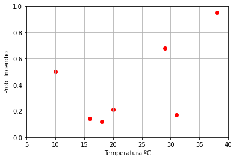

```
los coeficientes de regresión son b0  -0.028915304606240762 y b1 0.018348192174343733
```

```python
import numpy as np
import matplotlib.pyplot as plt

x = np.array([10, 18, 16, 20, 31, 29, 38])
y = np.array([0.5, 0.12, 0.14, 0.21, 0.17, 0.68, 0.95])

plt.scatter(x, y, color='red')
plt.xlim(5, 40), plt.ylim(0, 1), plt.grid()
plt.xlabel('Temperatura ºC'), plt.ylabel('Prob. Incendio')
plt.show()

b1 = np.sum( (x-np.mean(x))*(y-np.mean(y)) ) / np.sum( (x-np.mean(x))**2 )
b0 = (np.sum(y) - b1*np.sum(x)) / len(x)

print('los coeficientes de regresión son b0 ', b0, 'y b1', b1)
```

[output not shown]

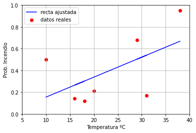

```python
b1, b0 = np.polyfit(x, y, 1) #regresion lineal en numpy

print('los coeficientes de regresión son b0 ', b0, 'y b1', b1)

yp = b0 + b1*x #calculo de variable dependiente con modelo de regresion

plt.scatter(x, y, label='datos reales', color='red')
plt.plot(x, yp, label='recta ajustada', color='blue')
plt.xlim(5, 40), plt.ylim(0, 1), plt.legend(), plt.grid()
plt.xlabel('Temperatura ºC'), plt.ylabel('Prob. Incendio')
plt.show()
```

# Inferencias a partir del modelo ajustado

## Inferencias sobre coeficientes de regresión

Para realizar inferencias sobre los parámetros $\beta_0$ y $\beta_1$ se requiere de una estimación para $\sigma^2$.

En este caso $\sigma^2$ representa la varianza entre todos los valores $(x_i, y_i)$ de la población y el modelo de regresión real $y = \beta_0 + \beta_1 x_1 + \epsilon$

Primero se definen:

\begin{align} S_{xx} & = \sum_{i=1}^{n} (x_i - \overline{x})^2 & S_{yy} & = \sum_{i=1}^{n} (y_i - \overline{y})^2 \end{align}\begin{align} S_{xy} = \sum_{i=1}^{n} (x_i - \overline{x}) (y_i - \overline{y}) \end{align}

Un estimador para $\sigma^2$ corresponde a $s^2$, que es igual a:

\begin{align} s^2 = \frac{\text{SCE}}{n-2} = \sum_{i=1}^n \frac{ ( y_i - \hat{y_i})^2 }{n-2} \end{align}

Este valor $s^2$ se conoce como **error cuadrático medio**.

Además se puede demostrar que:

\begin{align} s^2 = \frac{S_{yy} - b_1 S_{xy} }{n-2} \end{align}

Usando la distribución $t$ con $s^2$ como un estimador de $\sigma^2$ se puede demostrar que:

Los **intervalos de confianza** del $100(1-\alpha)\%$ para los parámetros $\beta_1$ y $\beta_0$ son respectivamente:

\begin{align} \beta_1 \in \left[ b_1 - t_{\alpha /2} \frac{s}{\sqrt{S_{xx}}} , b_1 + t_{\alpha /2} \frac{s}{\sqrt{S_{xx}}} \right] \end{align}

\begin{align} \beta_0 \in \left[ b_0 - t_{\alpha /2} \frac{s}{\sqrt{n S_{xx}}} \sqrt{\sum_{i=1}^{n} x_{i}^{2} } \hspace{0.5em} , \hspace{0.5em} b_0 + t_{\alpha /2} \frac{s}{\sqrt{n S_{xx}}} \sqrt{\sum_{i=1}^{n} x_{i}^{2} } \right] \end{align}

donde $t_{\alpha /2}$ es el valor que deja un área de $\alpha /2$ a la derecha de la distribución $t$ con $n-2$ grados de libertad

**Ejemplo**: Para el mismo conjunto de datos anterior, calcular los intervalos de confianza del 90% para $\beta_1$ y $\beta_0$

➤ Calculamos $t_{\alpha /2}$ para $n-2$ grados de libertad, donde $n=7$:

\begin{align} \nu & = 5 & \alpha & = 0.1 \end{align}\begin{align} t_{\alpha /2} = t_{0.05} = 2.015 \end{align}

➤ Calculamos $S_{xx}$, $S_{yy}$ y $S_{xy}$:

\begin{align} S_{xx} & = \sum_{i=1}^{n} (x_i - \overline{x})^2 = 576.86 & S_{xy} & = \sum_{i=1}^{n} (x_i - \overline{x}) (y_i - \overline{y}) = 10.58 \end{align}\begin{align} S_{yy} = \sum_{i=1}^{n} (y_i - \overline{y})^2 = 0.62577 \end{align}

➤ Calculamos el error cuadrático medio $s^2$:

\begin{align} s^2 = \frac{S_{yy} - b_1 S_{xy} }{n-2} = \frac{0.62577 - 0.01834 \cdot 10.58 }{7-2} = 0.08635 \rightarrow s = 0.29385 \end{align}

➤ Calculamos el intervalo de confianza para $\beta_1$:

\begin{align} \beta_1 \in \left[ b_1 - t_{\alpha /2} \frac{s}{\sqrt{S_{xx}}} , b_1 + t_{\alpha /2} \frac{s}{\sqrt{S_{xx}}} \right] \end{align}\begin{align} \beta_1 \in \left[ 0.01834 - 2.015 \frac{9.29385}{\sqrt{576.86}} , 0.01834 + 2.015 \frac{9.29385}{\sqrt{576.86}} \right] \end{align}\begin{align} \beta_1 \in \left[ -0.006, 0.043 \right] \end{align}

➤ Calculamos el intervalo de confianza para $\beta_0$:

\begin{align} \beta_0 \in \left[ b_0 - t_{\alpha /2} \frac{s}{\sqrt{n S_{xx}}} \sqrt{\sum_{i=1}^{n} x_{i}^{2} } \hspace{0.5em} , \hspace{0.5em} b_0 + t_{\alpha /2} \frac{s}{\sqrt{n S_{xx}}} \sqrt{\sum_{i=1}^{n} x_{i}^{2} } \right] \end{align}\begin{align} \beta_0 \in \left[ -0.02892 - 2.015 \frac{0.29385}{\sqrt{7 \cdot 576.86}} 65.7723 \hspace{0.5em} , \hspace{0.5em} -0.02892 + 2.015 \frac{0.29385}{\sqrt{7 \cdot 576.86}} 65.7723 \right] \end{align}\begin{align} \beta_0 \in \left[ -0.642 , 0.584 \right] \end{align}

## Intervalos de confianza y predicción

Dado un valor puntual $x_0$, es posible estimar un intervalo de confianza para la respuesta media de $y_0$ o un intervalo de predicción para el valor futuro de $y_0$

[figure not shown]

Dado $x_0$, el intervalo de confianza para la media $\mu_{y_0}$ es:

\begin{align} \mu_{y_0} \in \left[ \hat{y_0} - t_{\alpha /2} s \sqrt{ \frac{1}{n} + \frac{(x_0 - \overline{x})^2}{S_{xx}} } \hspace{0.5em} , \hspace{0.5em} \hat{y_0} + t_{\alpha /2} s \sqrt{ \frac{1}{n} + \frac{(x_0 - \overline{x})^2}{S_{xx}} } \right] \end{align}

donde $t_{\alpha /2}$ es el valor que deja un área de $\alpha /2$ a la derecha de la distribución $t$ con $n-2$ grados de libertad

Dado $x_0$, el intervalo de predicción para el valor $y_0$ es:

\begin{align} y_0 \in \left[ \hat{y_0} - t_{\alpha /2} s \sqrt{1 + \frac{1}{n} + \frac{(x_0 - \overline{x})^2}{S_{xx}} } \hspace{0.5em} , \hspace{0.5em} \hat{y_0} + t_{\alpha /2} s \sqrt{1 + \frac{1}{n} + \frac{(x_0 - \overline{x})^2}{S_{xx}} } \right] \end{align}

donde $t_{\alpha /2}$ es el valor que deja un área de $\alpha /2$ a la derecha de la distribución $t$ con $n-2$ grados de libertad

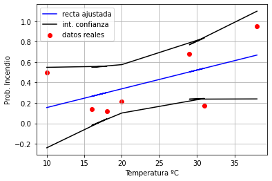

```python
t_a2 = 2.015
sxx = 576.86
s = 0.29385
n = 7

mu_min = np.array([y0 - t_a2*s*np.sqrt(1./n + ((x0-np.mean(x))**2)/sxx ) for x0, y0 in zip(x, yp)])
mu_max = np.array([y0 + t_a2*s*np.sqrt(1./n + ((x0-np.mean(x))**2)/sxx ) for x0, y0 in zip(x, yp)])

plt.scatter(x, y, label='datos reales', color='red')
plt.plot(x, yp, label='recta ajustada', color='blue')
plt.plot(x, mu_min, label='int. confianza', color='black')
plt.plot(x, mu_max,color='black')

plt.legend(), plt.grid()
plt.xlabel('Temperatura ºC'), plt.ylabel('Prob. Incendio')
plt.show()
```

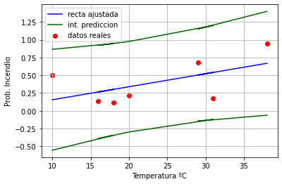

```python
y_min = np.array([y0 - t_a2*s*np.sqrt(1. + 1./n + ((x0-np.mean(x))**2)/sxx ) for x0, y0 in zip(x, yp)])
y_max = np.array([y0 + t_a2*s*np.sqrt(1. + 1./n + ((x0-np.mean(x))**2)/sxx ) for x0, y0 in zip(x, yp)])

plt.scatter(x, y, label='datos reales', color='red')
plt.plot(x, yp, label='recta ajustada', color='blue')
plt.plot(x, y_min, label='int. prediccion', color='darkgreen')
plt.plot(x, y_max, color='darkgreen')

plt.legend(), plt.grid()
plt.xlabel('Temperatura ºC'), plt.ylabel('Prob. Incendio')
plt.show()
```

# Métricas de desempeño

## Coeficiente de determinación

El **coeficiente de determinación** $R^2$ es una medida de la calidad del ajuste del modelo de regresión lineal.

\begin{align} R^2 = 1 - \frac{ \sum_{i=1}^n \left( y_i - \hat{y_i} \right)^2 }{ \sum_{i=1}^n \left( y_i - \overline{y_i} \right)^2 } \end{align}

Este coeficiente es una medida de la proporción de la variabilidad explicada por el modelo ajustado.

Un valor $R^2 = 1$ indica que el ajuste es muy bueno, mientras que valores $R^2 \approx 0$ indican un mal ajuste.

Buen ajuste (a) y mal ajuste (b)

[figure not shown]

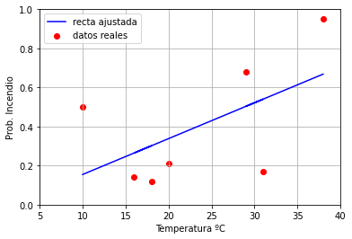

```
el coeficiente de determinación R2 es =  0.31034096388392085
```

```python
from sklearn.metrics import r2_score

plt.scatter(x, y, label='datos reales', color='red')
plt.plot(x, yp, label='recta ajustada', color='blue')
plt.xlim(5, 40), plt.ylim(0, 1), plt.legend(), plt.grid()
plt.xlabel('Temperatura ºC'), plt.ylabel('Prob. Incendio')
plt.show()

print('el coeficiente de determinación R2 es = ', r2_score(y, yp))
```

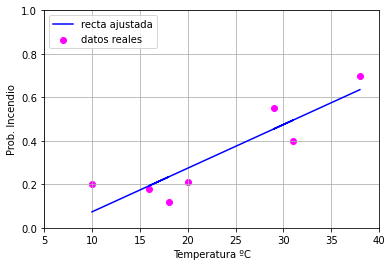

```
el coeficiente de determinación R2 es =  0.8068788987982256
```

```python
z = np.array([0.2, 0.12, 0.18, 0.21, 0.4, 0.55, 0.7])

b1z, b0z = np.polyfit(x, z, 1) #regresion lineal en numpy

zp = b0z + b1z*x #calculo de variable dependiente con modelo de regresion

plt.scatter(x, z, label='datos reales', color='magenta')
plt.plot(x, zp, label='recta ajustada', color='blue')
plt.xlim(5, 40), plt.ylim(0, 1), plt.legend(loc='upper left'), plt.grid()
plt.xlabel('Temperatura ºC'), plt.ylabel('Prob. Incendio')
plt.show()

print('el coeficiente de determinación R2 es = ', r2_score(z, zp))
```

# Regresión lineal múltiple

## Formulación vectorial

Una regresión lineal múltiple conecta $m$ variables independientes con una variable dependiente de la forma:

\begin{align} y = \beta_0 + \beta_1 x_1 + \beta_2 x_2 + \beta_3 x_3 + ... + \beta_m x_m + \epsilon \end{align}

Suponiendo que hay un total de $n$ datos $(x_{1i}, x_{2i}, ..., x_{mi}, y_i)$ con $i = 0, 1, ... n$ se puede escribir:

\begin{align} y_1 = \beta_0 + \beta_1 x_{11} + \beta_2 x_{21} + \beta_3 x_{31} + ... + \beta_m x_{m1} + \epsilon_1 \end{align}\begin{align} y_2 = \beta_0 + \beta_1 x_{12} + \beta_2 x_{22} + \beta_3 x_{32} + ... + \beta_m x_{m2} + \epsilon_2 \end{align}\begin{align} ... \end{align}\begin{align} y_n = \beta_0 + \beta_1 x_{1n} + \beta_2 x_{2n} + \beta_3 x_{3n} + ... + \beta_m x_{mn} + \epsilon_n \end{align}

Estas ecuaciones se pueden resumir de forma matricial como sigue:

\begin{split} \begin{pmatrix} y_{1} \\ y_{2} \\ ... \\ y_{n} \end{pmatrix} = \begin{pmatrix} 1 & x_{11} & x_{21} & ... & x_{m1} \\ 1 & x_{12} & x_{22} & ... & x_{m2} \\ ... & ... & ... & ... \\ 1 & x_{1n} & x_{2n} & ... & x_{mn} \end{pmatrix} \begin{pmatrix} \beta_{0} \\ \beta_{1} \\ ... \\ \beta_{m} \end{pmatrix} + \begin{pmatrix} \epsilon_{1} \\ \epsilon_{2} \\ ... \\ \epsilon_{n} \end{pmatrix} \end{split}

Además, en notación vectorial se pueden resumir como sigue:

\begin{align} \mathbf{y} = \mathbf{X} \boldsymbol{\beta} + \boldsymbol{\epsilon} \end{align}

Para el caso del modelo ajustado a la muestra se tiene:

\begin{align} \mathbf{\hat{y}} = \mathbf{X} \mathbf{b} \end{align}

## Resolución por mínimos cuadrados

Se puede demostrar que:

\begin{align} \text{SCE} = (\mathbf{y} - \mathbf{X} \mathbf{b})^{T} (\mathbf{y} - \mathbf{X} \mathbf{b}) \end{align}

En un siguiente paso se debe minimizar la suma de los errores al cuadrado mediante:

\begin{align} \frac{\partial \text{SCE}}{\partial \mathbf{b}} & = \mathbf{0} \end{align}

Resolviendo esta ecuación se obtiene una expresión para los coeficientes:

\begin{split} \mathbf{b} = (\mathbf{X^{T}} \mathbf{X)^{-1}} \mathbf{X^{T}} \mathbf{y} = \mathbf{P} \mathbf{y} \end{split}

, donde $\mathbf{P} = (\mathbf{X}^{T} \mathbf{X})^{-1} \mathbf{X}^{T}$ se conoce como matriz pseudoinversa

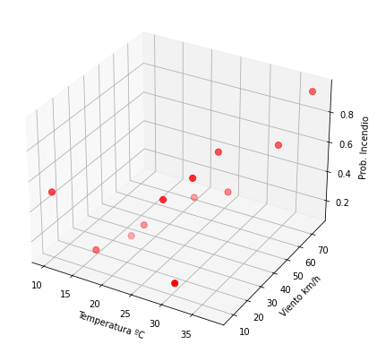

```python
x1 = np.array([10, 18, 16, 20, 31, 29, 38, 30, 25, 36, 25, 28]) #temperatura
x2 = np.array([10, 31, 15, 32, 8, 47, 76, 50, 47, 60, 25, 33]) #viento
y = np.array([0.5, 0.12, 0.14, 0.21, 0.17, 0.68, 0.95, 0.4, 0.33, 0.7, 0.5, 0.61]) #prob incendio

#%matplotlib qt
fig = plt.figure(figsize = (10, 7))
ax = fig.add_subplot(projection='3d')
ax.scatter(x1, x2, y, color='red', marker='o', s=50)
ax.set_xlabel('Temperatura ºC'), ax.set_ylabel('Viento km/h'), ax.set_zlabel('Prob. Incendio')
plt.show()
```

```python
print('*Calculo de coeficientes*')
xmat = np.column_stack((np.ones(12), x1, x2)) #forma matriz X
pinv = np.linalg.pinv(xmat) #calcula pseudoinversa
b = np.dot(pinv, y) #calcula coeficientes

print('    Los coeficientes son: b0 = ', b[0], ' b1 = ', b[1], ' b2 = ', b[2])

print('\n*Calculo de un caso puntual para x1=32 y x2=47*')
yp_puntual = b[0] + b[1]*32 + b[2]*47

print('    Para temperatura de 32º y viento de 47 km/h la probabilidad de incendio es = ', yp_puntual)
```

```
*Calculo de coeficientes*
    Los coeficientes son: b0 =  0.02405775065078994  b1 =  0.006697055225268672  b2 =  0.006847944915341728

*Calculo de un caso puntual para x1=32 y x2=47*
    Para temperatura de 32º y viento de 47 km/h la probabilidad de incendio es =  0.5602169288804486
```

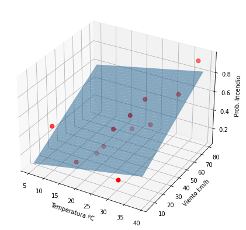

```python
x1m, x2m = np.meshgrid(np.arange(5, 40, 1), np.arange(5, 80, 1))
ypm = b[0] + b[1]*x1m + b[2]*x2m

#%matplotlib qt
fig = plt.figure(figsize = (10, 7))
ax = fig.add_subplot(projection='3d')
ax.scatter(x1, x2, y, color='red', marker='o', s=50)
ax.plot_surface(x1m, x2m, ypm, alpha=0.5)
ax.set_xlabel('Temperatura ºC'), ax.set_ylabel('Viento km/h'), ax.set_zlabel('Prob. Incendio')
plt.show()
```

# Sumario

- Las regresiones lineales son modelos matemáticos que aproximan una variable dependiente a través de una o varias variables independientes usando combinaciones lineales.
- Ya que el modelo se genera a partir de una muestra de los datos, se pueden usar herramientas estadísticas para inferir cómo sería el modelo con todos los datos de la población.
- Los coeficientes de un modelo se obtienen mediante el método de los mínimos cuadrados.
- La calidad de un modelo ajustado se puede medir mediante el coeficiente de determinación.